# Bank_Churn_Prediction_Full_code

Bank Churn Prediction

## Problem Statement

### Context

Businesses like banks which provide service have to worry about problem of 'Customer Churn' i.e. customers leaving and joining another service provider. It is important to understand which aspects of the service influence a customer's decision in this regard. Management can concentrate efforts on improvement of service, keeping in mind these priorities.

### Objective

You as a Data scientist with the bank need to build a neural network based classifier that can determine whether a customer will leave the bank or not in the next 6 months.

### Data Dictionary

- CustomerId: Unique ID which is assigned to each customer
- Surname: Last name of the customer
- CreditScore: It defines the credit history of the customer.
- Geography: A customer’s location
- Gender: It defines the Gender of the customer
- Age: Age of the customer
- Tenure: Number of years for which the customer has been with the bank
- NumOfProducts: refers to the number of products that a customer has purchased through the bank.
- Balance: Account balance
- HasCrCard: It is a categorical variable which decides whether the customer has credit card or not.
- EstimatedSalary: Estimated salary
- isActiveMember: Is is a categorical variable which decides whether the customer is active member of the bank or not ( Active member in the sense, using bank products regularly, making transactions etc )
- Exited : whether or not the customer left the bank within six month. It can take two values **0=No ( Customer did not leave the bank )** 1=Yes ( Customer left the bank )

## Importing necessary libraries

```python
#Installing the libraries with the specified version.
!pip install tensorflow==2.15.0 scikit-learn==1.2.2 seaborn==0.13.1 matplotlib==3.7.1 numpy==1.24.1 pandas==1.5.3 -q --user --no-warn-script-location
```

[output not shown]

```python
# Library for data manipulation and analysis.
import pandas as pd
# Fundamental package for scientific computing.
import numpy as np
#splitting datasets into training and testing sets.
from sklearn.model_selection import train_test_split
#Imports tools for data preprocessing including label encoding, one-hot encoding, and standard scaling
from sklearn.preprocessing import LabelEncoder, OneHotEncoder,StandardScaler
#Imports a class for imputing missing values in datasets.
from sklearn.impute import SimpleImputer
#Imports the Matplotlib library for creating visualizations.
import matplotlib.pyplot as plt
# Imports the Seaborn library for statistical data visualization.
import seaborn as sns
# Time related functions.
import time
#Imports functions for evaluating the performance of machine learning models
from sklearn.metrics import confusion_matrix, f1_score,accuracy_score, recall_score, precision_score, classification_report


#Imports the tensorflow,keras and layers.
import tensorflow
import tensorflow as tf
from tensorflow.keras.models import Sequential
from tensorflow.keras.layers import Dense
from tensorflow.keras.layers import Dense, Input, Dropout,BatchNormalization
from tensorflow.keras import backend

# to suppress unnecessary warnings
import warnings
warnings.filterwarnings("ignore")
```

```python
from google.colab import drive
drive.mount('/content/drive')
```

## Loading the dataset

```python
# loading the dataset
df = pd.read_csv("/content/drive/MyDrive/Colab Notebooks/Churn.csv")
```

## Data Overview

```python
# Displaying the first 5 rows of the dataset
df.head()
```

|  | RowNumber | CustomerId | Surname | CreditScore | Geography | Gender | Age | Tenure | Balance | NumOfProducts | HasCrCard | IsActiveMember | EstimatedSalary | Exited |
| --- | --- | --- | --- | --- | --- | --- | --- | --- | --- | --- | --- | --- | --- | --- |
| 0 | 1 | 15634602 | Hargrave | 619 | France | Female | 42 | 2 | 0.00 | 1 | 1 | 1 | 101348.88 | 1 |
| 1 | 2 | 15647311 | Hill | 608 | Spain | Female | 41 | 1 | 83807.86 | 1 | 0 | 1 | 112542.58 | 0 |
| 2 | 3 | 15619304 | Onio | 502 | France | Female | 42 | 8 | 159660.80 | 3 | 1 | 0 | 113931.57 | 1 |
| 3 | 4 | 15701354 | Boni | 699 | France | Female | 39 | 1 | 0.00 | 2 | 0 | 0 | 93826.63 | 0 |
| 4 | 5 | 15737888 | Mitchell | 850 | Spain | Female | 43 | 2 | 125510.82 | 1 | 1 | 1 | 79084.10 | 0 |

```python
# Displaying the last 5 rows of the data set
df.tail()
```

|  | RowNumber | CustomerId | Surname | CreditScore | Geography | Gender | Age | Tenure | Balance | NumOfProducts | HasCrCard | IsActiveMember | EstimatedSalary | Exited |
| --- | --- | --- | --- | --- | --- | --- | --- | --- | --- | --- | --- | --- | --- | --- |
| 9995 | 9996 | 15606229 | Obijiaku | 771 | France | Male | 39 | 5 | 0.00 | 2 | 1 | 0 | 96270.64 | 0 |
| 9996 | 9997 | 15569892 | Johnstone | 516 | France | Male | 35 | 10 | 57369.61 | 1 | 1 | 1 | 101699.77 | 0 |
| 9997 | 9998 | 15584532 | Liu | 709 | France | Female | 36 | 7 | 0.00 | 1 | 0 | 1 | 42085.58 | 1 |
| 9998 | 9999 | 15682355 | Sabbatini | 772 | Germany | Male | 42 | 3 | 75075.31 | 2 | 1 | 0 | 92888.52 | 1 |
| 9999 | 10000 | 15628319 | Walker | 792 | France | Female | 28 | 4 | 130142.79 | 1 | 1 | 0 | 38190.78 | 0 |

```python
# Checking the shape of the dataset
print(f"There are {df.shape[0]} rows and {df.shape[1]} columns.")
```

```
There are 10000 rows and 14 columns.
```

```python
# Displaying 10 random rows from the dataset
df.sample(n=10, random_state=1)
```

|  | RowNumber | CustomerId | Surname | CreditScore | Geography | Gender | Age | Tenure | Balance | NumOfProducts | HasCrCard | IsActiveMember | EstimatedSalary | Exited |
| --- | --- | --- | --- | --- | --- | --- | --- | --- | --- | --- | --- | --- | --- | --- |
| 9953 | 9954 | 15655952 | Burke | 550 | France | Male | 47 | 2 | 0.00 | 2 | 1 | 1 | 97057.28 | 0 |
| 3850 | 3851 | 15775293 | Stephenson | 680 | France | Male | 34 | 3 | 143292.95 | 1 | 1 | 0 | 66526.01 | 0 |
| 4962 | 4963 | 15665088 | Gordon | 531 | France | Female | 42 | 2 | 0.00 | 2 | 0 | 1 | 90537.47 | 0 |
| 3886 | 3887 | 15720941 | Tien | 710 | Germany | Male | 34 | 8 | 147833.30 | 2 | 0 | 1 | 1561.58 | 0 |
| 5437 | 5438 | 15733476 | Gonzalez | 543 | Germany | Male | 30 | 6 | 73481.05 | 1 | 1 | 1 | 176692.65 | 0 |
| 8517 | 8518 | 15671800 | Robinson | 688 | France | Male | 20 | 8 | 137624.40 | 2 | 1 | 1 | 197582.79 | 0 |
| 2041 | 2042 | 15709846 | Yeh | 840 | France | Female | 39 | 1 | 94968.97 | 1 | 1 | 0 | 84487.62 | 0 |
| 1989 | 1990 | 15622454 | Zaitsev | 695 | Spain | Male | 28 | 0 | 96020.86 | 1 | 1 | 1 | 57992.49 | 0 |
| 1933 | 1934 | 15815560 | Bogle | 666 | Germany | Male | 74 | 7 | 105102.50 | 1 | 1 | 1 | 46172.47 | 0 |
| 9984 | 9985 | 15696175 | Echezonachukwu | 602 | Germany | Male | 35 | 7 | 90602.42 | 2 | 1 | 1 | 51695.41 | 0 |

```python
# Checking the data types & non-null values of the dataset
df.info()
```

```
<class 'pandas.core.frame.DataFrame'>
RangeIndex: 10000 entries, 0 to 9999
Data columns (total 14 columns):
 #   Column           Non-Null Count  Dtype
---  ------           --------------  -----
 0   RowNumber        10000 non-null  int64
 1   CustomerId       10000 non-null  int64
 2   Surname          10000 non-null  object
 3   CreditScore      10000 non-null  int64
 4   Geography        10000 non-null  object
 5   Gender           10000 non-null  object
 6   Age              10000 non-null  int64
 7   Tenure           10000 non-null  int64
 8   Balance          10000 non-null  float64
 9   NumOfProducts    10000 non-null  int64
 10  HasCrCard        10000 non-null  int64
 11  IsActiveMember   10000 non-null  int64
 12  EstimatedSalary  10000 non-null  float64
 13  Exited           10000 non-null  int64
dtypes: float64(2), int64(9), object(3)
memory usage: 1.1+ MB
```

- There are 0 missing values throughout the dataset.
- The datatypes that are present are: int, object, and float.

#### Checking for any duplicate values

```python
df.duplicated().sum()
```

```
0
```

- There are not values that are exactly the same throughout the data.

#### Checking for missing values

```python
df.isnull().sum()
```

|  | 0 |
| --- | --- |
| RowNumber | 0 |
| CustomerId | 0 |
| Surname | 0 |
| CreditScore | 0 |
| Geography | 0 |
| Gender | 0 |
| Age | 0 |
| Tenure | 0 |
| Balance | 0 |
| NumOfProducts | 0 |
| HasCrCard | 0 |
| IsActiveMember | 0 |
| EstimatedSalary | 0 |
| Exited | 0 |

**dtype:** int64

- There are no missing values present in any of the columns

```python
df["Exited"].value_counts()
```

| Exited | count |
| --- | --- |
| 0 | 7963 |
| 1 | 2037 |

**dtype:** int64

- There is a significant imballance between those who are still with the bank and customers who have left. An approx 80/20 ratio.

```python
# Statistical summary of the numerical columns in the data
df.describe().T
```

|  | count | mean | std | min | 25% | 50% | 75% | max |
| --- | --- | --- | --- | --- | --- | --- | --- | --- |
| RowNumber | 10000.0 | 5.000500e+03 | 2886.895680 | 1.00 | 2500.75 | 5.000500e+03 | 7.500250e+03 | 10000.00 |
| CustomerId | 10000.0 | 1.569094e+07 | 71936.186123 | 15565701.00 | 15628528.25 | 1.569074e+07 | 1.575323e+07 | 15815690.00 |
| CreditScore | 10000.0 | 6.505288e+02 | 96.653299 | 350.00 | 584.00 | 6.520000e+02 | 7.180000e+02 | 850.00 |
| Age | 10000.0 | 3.892180e+01 | 10.487806 | 18.00 | 32.00 | 3.700000e+01 | 4.400000e+01 | 92.00 |
| Tenure | 10000.0 | 5.012800e+00 | 2.892174 | 0.00 | 3.00 | 5.000000e+00 | 7.000000e+00 | 10.00 |
| Balance | 10000.0 | 7.648589e+04 | 62397.405202 | 0.00 | 0.00 | 9.719854e+04 | 1.276442e+05 | 250898.09 |
| NumOfProducts | 10000.0 | 1.530200e+00 | 0.581654 | 1.00 | 1.00 | 1.000000e+00 | 2.000000e+00 | 4.00 |
| HasCrCard | 10000.0 | 7.055000e-01 | 0.455840 | 0.00 | 0.00 | 1.000000e+00 | 1.000000e+00 | 1.00 |
| IsActiveMember | 10000.0 | 5.151000e-01 | 0.499797 | 0.00 | 0.00 | 1.000000e+00 | 1.000000e+00 | 1.00 |
| EstimatedSalary | 10000.0 | 1.000902e+05 | 57510.492818 | 11.58 | 51002.11 | 1.001939e+05 | 1.493882e+05 | 199992.48 |
| Exited | 10000.0 | 2.037000e-01 | 0.402769 | 0.00 | 0.00 | 0.000000e+00 | 0.000000e+00 | 1.00 |

- The max age is 92, which is a significant high age to be a part of a bank.
- RowNumber & CustomerID are columns that should be removed due to their statiscital summary consisting of numbers thata are random and irrelevant.

```python
# Check the unique values in each column
df.nunique()
```

|  | 0 |
| --- | --- |
| RowNumber | 10000 |
| CustomerId | 10000 |
| Surname | 2932 |
| CreditScore | 460 |
| Geography | 3 |
| Gender | 2 |
| Age | 70 |
| Tenure | 11 |
| Balance | 6382 |
| NumOfProducts | 4 |
| HasCrCard | 2 |
| IsActiveMember | 2 |
| EstimatedSalary | 9999 |
| Exited | 2 |

**dtype:** int64

- For the surname unique count being a low amount compared ot the total number of rows in teh data set, the shows that there are a number of customers who share the same surnames.

```python
for i in df.describe(include=["object"]).columns:
    print("Unique values in", i, "are :")
    print(df[i].value_counts())
    print("*" * 50)
```

```
Unique values in Surname are :
Surname
Smith       32
Scott       29
Martin      29
Walker      28
Brown       26
            ..
Izmailov     1
Bold         1
Bonham       1
Poninski     1
Burbidge     1
Name: count, Length: 2932, dtype: int64
Unique values in Geography are :
Geography
France     5014
Germany    2509
Spain      2477
Name: count, dtype: int64
Unique values in Gender are :
Gender
Male      5457
Female    4543
Name: count, dtype: int64
```

- France has the most customers that reside, almost double the amount of each germany and spain residents.
- There is almost a thousand indivual differnce between male and female cusotmers in this data set.

## Exploratory Data Analysis

#### Functions to help with visualizing the EDA

```python
# function to plot a boxplot and a histogram along the same scale.


def histogram_boxplot(data, feature, figsize=(12, 7), kde=False, bins=None):
    """
    Boxplot and histogram combined

    data: dataframe
    feature: dataframe column
    figsize: size of figure (default (12,7))
    kde: whether to the show density curve (default False)
    bins: number of bins for histogram (default None)
    """
    f2, (ax_box2, ax_hist2) = plt.subplots(
        nrows=2,  # Number of rows of the subplot grid= 2
        sharex=True,  # x-axis will be shared among all subplots
        gridspec_kw={"height_ratios": (0.25, 0.75)},
        figsize=figsize,
    )  # creating the 2 subplots
    sns.boxplot(
        data=data, x=feature, ax=ax_box2, showmeans=True, color="violet"
    )  # boxplot will be created and a triangle will indicate the mean value of the column
    sns.histplot(
        data=data, x=feature, kde=kde, ax=ax_hist2, bins=bins, palette="winter"
    ) if bins else sns.histplot(
        data=data, x=feature, kde=kde, ax=ax_hist2
    )  # For histogram
    ax_hist2.axvline(
        data[feature].mean(), color="green", linestyle="--"
    )  # Add mean to the histogram
    ax_hist2.axvline(
        data[feature].median(), color="black", linestyle="-"
    )  # Add median to the histogram
```

```python
# function to create labeled barplots


def labeled_barplot(data, feature, perc=False, n=None):
    """
    Barplot with percentage at the top

    data: dataframe
    feature: dataframe column
    perc: whether to display percentages instead of count (default is False)
    n: displays the top n category levels (default is None, i.e., display all levels)
    """

    total = len(data[feature])  # length of the column
    count = data[feature].nunique()
    if n is None:
        plt.figure(figsize=(count + 1, 5))
    else:
        plt.figure(figsize=(n + 1, 5))

    plt.xticks(rotation=90, fontsize=15)
    ax = sns.countplot(
        data=data,
        x=feature,
        palette="Paired",
        order=data[feature].value_counts().index[:n].sort_values(),
    )

    for p in ax.patches:
        if perc == True:
            label = "{:.1f}%".format(
                100 * p.get_height() / total
            )  # percentage of each class of the category
        else:
            label = p.get_height()  # count of each level of the category

        x = p.get_x() + p.get_width() / 2  # width of the plot
        y = p.get_height()  # height of the plot

        ax.annotate(
            label,
            (x, y),
            ha="center",
            va="center",
            size=12,
            xytext=(0, 5),
            textcoords="offset points",
        )  # annotate the percentage

    plt.show()  # show the plot
```

```python
# function to plot stacked bar chart

def stacked_barplot(data, predictor, target):
    """
    Print the category counts and plot a stacked bar chart

    data: dataframe
    predictor: independent variable
    target: target variable
    """
    count = data[predictor].nunique()
    sorter = data[target].value_counts().index[-1]
    tab1 = pd.crosstab(data[predictor], data[target], margins=True).sort_values(
        by=sorter, ascending=False
    )
    print(tab1)
    print("-" * 120)
    tab = pd.crosstab(data[predictor], data[target], normalize="index").sort_values(
        by=sorter, ascending=False
    )
    tab.plot(kind="bar", stacked=True, figsize=(count + 1, 5))
    plt.legend(
        loc="lower left", frameon=False,
    )
    plt.legend(loc="upper left", bbox_to_anchor=(1, 1))
    plt.show()
```

```python
# function to plot a boxplot and a histogram along the same scale.


def histogram_boxplot(data, feature, figsize=(12, 7), kde=False, bins=None):
    """
    Boxplot and histogram combined

    data: dataframe
    feature: dataframe column
    figsize: size of figure (default (12,7))
    kde: whether to the show density curve (default False)
    bins: number of bins for histogram (default None)
    """
    f2, (ax_box2, ax_hist2) = plt.subplots(
        nrows=2,  # Number of rows of the subplot grid= 2
        sharex=True,  # x-axis will be shared among all subplots
        gridspec_kw={"height_ratios": (0.25, 0.75)},
        figsize=figsize,
    )  # creating the 2 subplots
    sns.boxplot(
        data=data, x=feature, ax=ax_box2, showmeans=True, color="violet"
    )  # boxplot will be created and a star will indicate the mean value of the column
    sns.histplot(
        data=data, x=feature, kde=kde, ax=ax_hist2, bins=bins, palette="winter"
    ) if bins else sns.histplot(
        data=data, x=feature, kde=kde, ax=ax_hist2
    )  # For histogram
    ax_hist2.axvline(
        data[feature].mean(), color="green", linestyle="--"
    )  # Add mean to the histogram
    ax_hist2.axvline(
        data[feature].median(), color="black", linestyle="-"
    )  # Add median to the histogram
```

```python
### Function to plot distributions


def distribution_plot_wrt_target(data, predictor, target):

    fig, axs = plt.subplots(2, 2, figsize=(12, 10))

    target_uniq = data[target].unique()

    axs[0, 0].set_title("Distribution of target for target=" + str(target_uniq[0]))
    sns.histplot(
        data=data[data[target] == target_uniq[0]],
        x=predictor,
        kde=True,
        ax=axs[0, 0],
        color="teal",
    )

    axs[0, 1].set_title("Distribution of target for target=" + str(target_uniq[1]))
    sns.histplot(
        data=data[data[target] == target_uniq[1]],
        x=predictor,
        kde=True,
        ax=axs[0, 1],
        color="orange",
    )

    axs[1, 0].set_title("Boxplot w.r.t target")
    sns.boxplot(data=data, x=target, y=predictor, ax=axs[1, 0], palette="gist_rainbow")

    axs[1, 1].set_title("Boxplot (without outliers) w.r.t target")
    sns.boxplot(
        data=data,
        x=target,
        y=predictor,
        ax=axs[1, 1],
        showfliers=False,
        palette="gist_rainbow",
    )

    plt.tight_layout()
    plt.show()
```

### Univariate Analysis

#### `CreditScore`

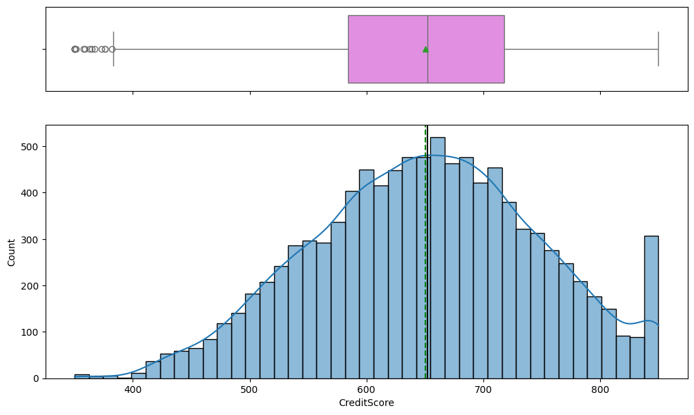

```python
histogram_boxplot(df, "CreditScore", kde=True)
```

- The distribution is skewed a little towards the left as well as slighltly normally distributed.

#### `Geography`

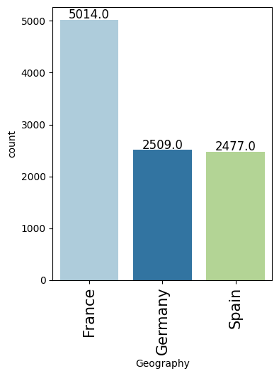

```python
labeled_barplot(df, "Geography")
```

- From the dataset, there are twice the amount of customers living in france compared to Germany & Spain.

#### `Age`

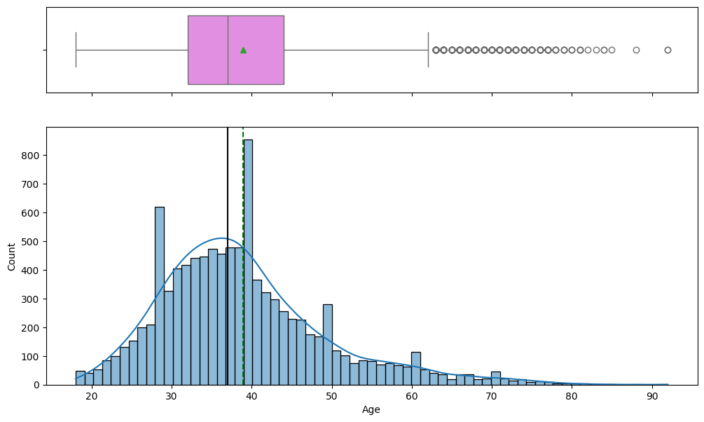

```python
histogram_boxplot(df, "Age", kde=True)
```

- The data is skewed to the right.
- The average age of customers is around 35-38 years old.

#### `Tenure`

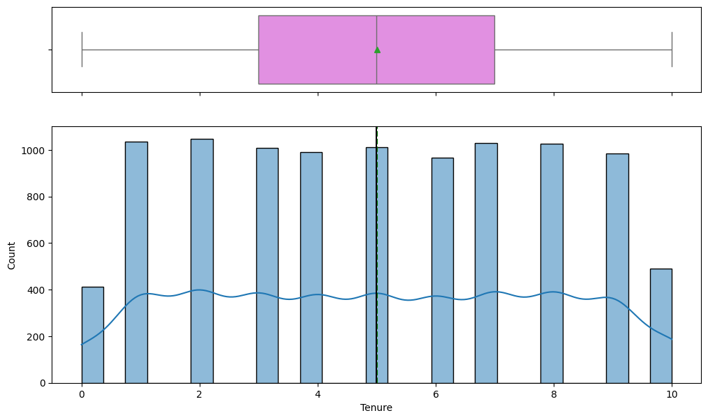

```python
histogram_boxplot(df, "Tenure", kde=True)
```

#### `NumOfProducts`

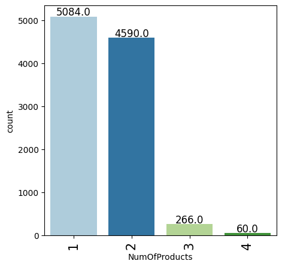

```python
labeled_barplot(df, "NumOfProducts")
```

- As seen above, there a significant amount of customers who purchase between 1 to 2 procuts through the bank, most customers do not buy more than that amount.

#### `Balance`

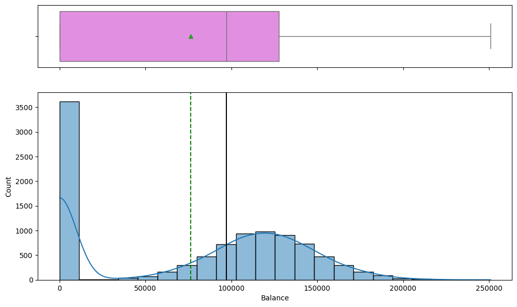

```python
histogram_boxplot(df, "Balance", kde=True)
```

- From the above histogram & boxplot, there are a vast amount of customers who have a balance of 0 which seems to be a mistake in the dataset.
- Excluding the 0 count, the data is normally distributed with no skewness, as seen in the histogram.

#### `HasCrCard`

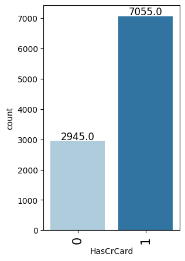

```python
labeled_barplot(df, "HasCrCard")
```

- There is more than twice the amount of customers who have credit cards than those who do not.

#### `isActiveMember`

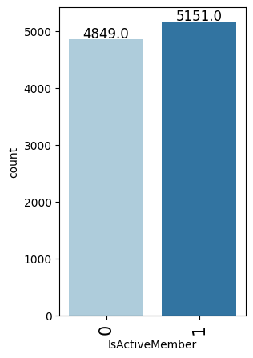

```python
labeled_barplot(df, "IsActiveMember")
```

- There is almost a balance between customers who are active compared to those who are not.

#### `Exited`

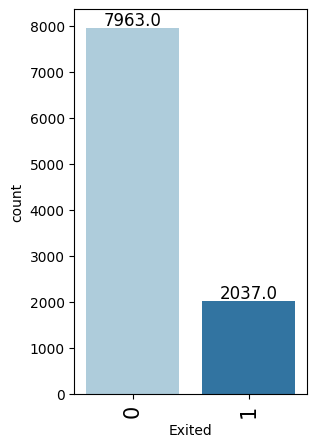

```python
labeled_barplot(df, "Exited")
```

### Bivariate Analysis

#### Correlation between numerical variables

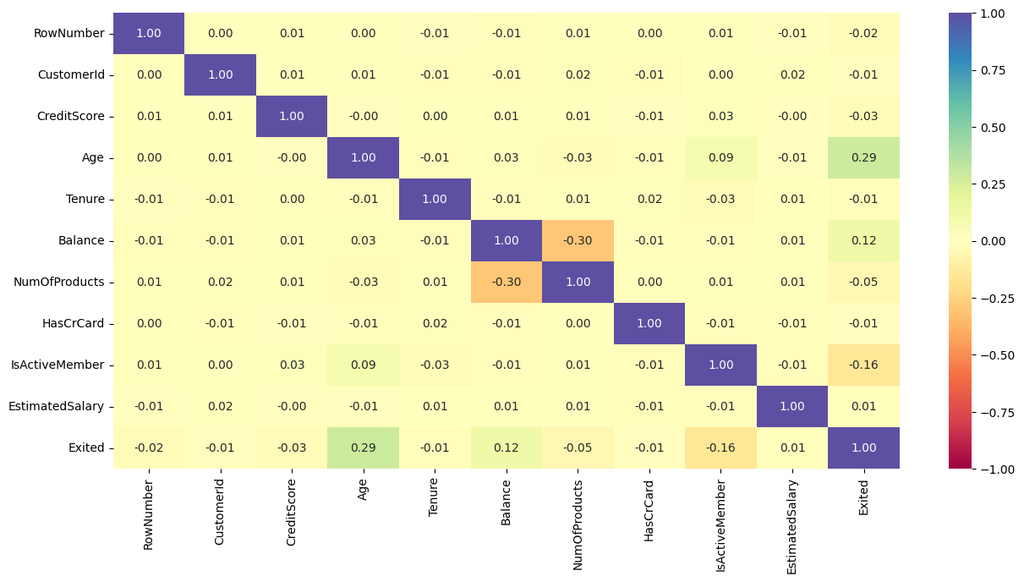

```python
numerical_df = df.select_dtypes(include=['number'])
plt.figure(figsize=(15, 7))
sns.heatmap(
    numerical_df.corr(), annot=True, vmin=-1, vmax=1, fmt=".2f", cmap="Spectral"
)
plt.show()
```

#### `Exited` vs `CreditScore`

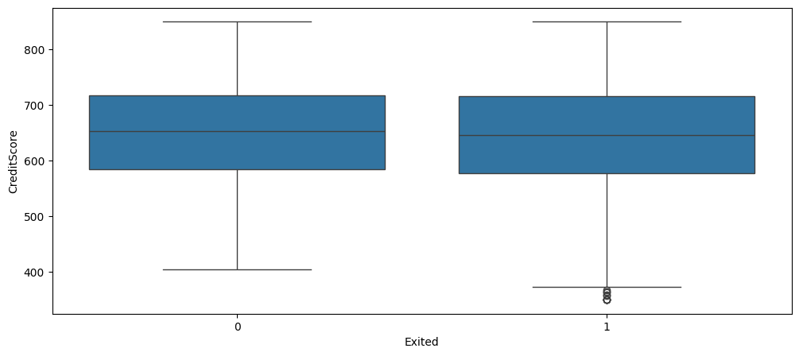

```python
plt.figure(figsize=(12, 5))
sns.boxplot(x="Exited", y="CreditScore", data=df)  # Use sns.boxplot for a boxplot
plt.show()
```

- As seen above, there is no difference on the credit score for customers who are still apart with the bank and those who are not.

#### `Exited` vs `Geography`

```
Exited        0     1    All
Geography
All        7963  2037  10000
Germany    1695   814   2509
France     4204   810   5014
Spain      2064   413   2477
------------------------------------------------------------------------------------------------------------------------
```

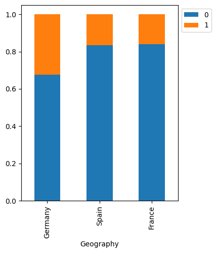

```python
stacked_barplot(df, "Geography", "Exited")
```

- From the above barplot, those customers who reside in Germany have the most amount of leaving the bank.

#### `Exited` vs `Gender`

```
Exited     0     1    All
Gender
All     7963  2037  10000
Female  3404  1139   4543
Male    4559   898   5457
------------------------------------------------------------------------------------------------------------------------
```

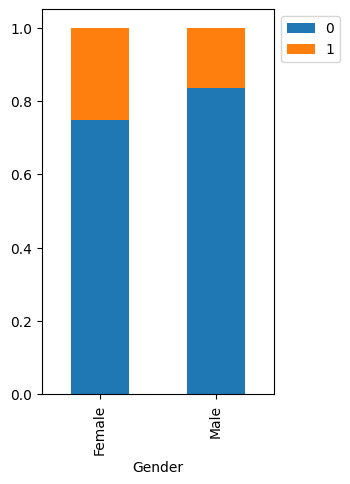

```python
# Exited vs gender analysis
stacked_barplot(df, "Gender", "Exited")
```

- The male and femal for those who are still with the bank and are not do not have too much of a differne. Although, there are more males who are still with the bank than those who are not.

#### `Exited` vs `Age`

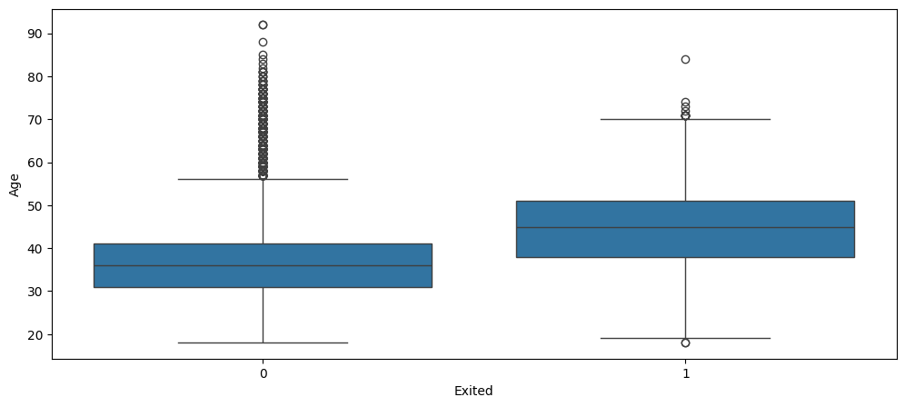

```python
# Exited and age analyis
plt.figure(figsize=(12, 5))
sns.boxplot(x="Exited", y="Age", data=df)  # Use sns.boxplot for a boxplot
plt.show()
```

- From the above bar plot, those customers who have left the bank tend to be much older than those who are still with the bank.
- This could be because they have spent more time with the bank, an those who are still with the bank are new and young.
- There are also a significant amount of outliers with those who are still with the bank, which will need to be looked at.

#### `Exited` vs `Tenure`

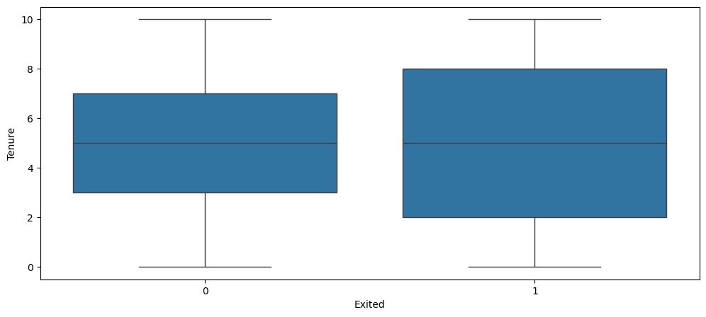

```python
# Tenure vs age analysis
plt.figure(figsize=(12, 5))
sns.boxplot(x="Exited", y="Tenure", data=df)  # Use sns.boxplot for a boxplot
plt.show()
```

- The customers who are still with the bank has a smaller range of loyality with the bank (3,7).
- Those customers who are not with the bank have a larger range of years with the customer (2-8), this could be because they are much older and experienced.

#### `Exited` vs `NumOfProducts`

```
Exited            0     1    All
NumOfProducts
All            7963  2037  10000
1              3675  1409   5084
2              4242   348   4590
3                46   220    266
4                 0    60     60
------------------------------------------------------------------------------------------------------------------------
```

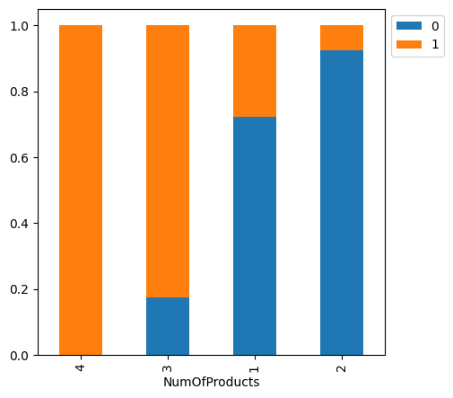

```python
# Analysis between num of products and exited
stacked_barplot(df, "NumOfProducts", "Exited")
```

- Those custoemrs who are not with the bank have a much more amount of products with the bank between 3-4. On the contrary those customers who are still with the bank have a more smaller amount 1-2.